# Packages

```python
import random
import numpy as np
import pandas as pd
import matplotlib.pyplot as plt
from sklearn.cluster import KMeans
from sklearn.metrics import confusion_matrix
import seaborn as sns
```

# Task A: Iris Data

Perform K-Means clustering on the dataset, iris.csv (from the UCI Machine Learning Repository). Before using the data for clustering, you might have to remove a few columns because the K-Means algorithm involves the calculation of Euclidian distance. You can choose various values of K; however, you must also choose K = 3 in this case. Upon clustering at K = 3, check how much similar your three clusters are as compared to the labels of species – setosa, versicolour, and verginic

```python
iris = pd.read_csv("Unit06 iris.csv")
iris.head(5)
```

|  | sepal_length | sepal_width | petal_length | petal_width | species |
| --- | --- | --- | --- | --- | --- |
| 0 | 5.1 | 3.5 | 1.4 | 0.2 | setosa |
| 1 | 4.9 | 3.0 | 1.4 | 0.2 | setosa |
| 2 | 4.7 | 3.2 | 1.3 | 0.2 | setosa |
| 3 | 4.6 | 3.1 | 1.5 | 0.2 | setosa |
| 4 | 5.0 | 3.6 | 1.4 | 0.2 | setosa |

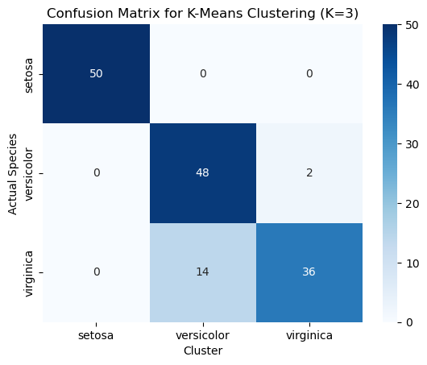

```python
iris_features = iris.drop(columns=['species'])

kmeans = KMeans(n_clusters=3, random_state=0)
kmeans.fit(iris_features)

cluster_labels = kmeans.labels_

iris['cluster'] = cluster_labels

species_mode = iris.groupby('cluster')['species'].apply(lambda x: x.mode().iloc[0]).to_dict()

iris['cluster_species'] = iris['cluster'].map(species_mode)

conf_matrix = confusion_matrix(iris['species'], iris['cluster_species'])

sns.heatmap(conf_matrix, annot=True, fmt='d', cmap='Blues',
            xticklabels=np.unique(iris['cluster_species']),
            yticklabels=np.unique(iris['species']))
plt.xlabel('Cluster')
plt.ylabel('Actual Species')
plt.title('Confusion Matrix for K-Means Clustering (K=3)')
plt.show()
```

## Iris Data Conclusion

The K-means clustering in the confusion matrix above shows the various groupings based on feature. It shows a solid separation of the "Setosa" along with some overlap of the "Versicolor" and "Virginia" which suggests they have similar features, this overall showing that the K-Means has identified the overlaps in the data.

# Task B: Wine Data

Perform K-Means clustering on the dataset, wine.csv (from the UCI Machine Learning Repository). Before using the data for clustering, you might have to remove a few columns like in the previous task. You can choose various values of K; however, you must also choose K = 3 in this case. Upon clustering at K = 3, check how much similar your three clusters are as compared to the labels of wines – 1, 2, and 3.

```python
wine = pd.read_csv("Unit06 wine.csv")
wine.head(5)
```

|  | Wine | Alcohol | Malic.acid | Ash | Acl | Mg | Phenols | Flavanoids | Nonflavanoid.phenols | Proanth | Color.int | Hue | OD | Proline |
| --- | --- | --- | --- | --- | --- | --- | --- | --- | --- | --- | --- | --- | --- | --- |
| 0 | 1 | 14.23 | 1.71 | 2.43 | 15.6 | 127 | 2.80 | 3.06 | 0.28 | 2.29 | 5.64 | 1.04 | 3.92 | 1065 |
| 1 | 1 | 13.20 | 1.78 | 2.14 | 11.2 | 100 | 2.65 | 2.76 | 0.26 | 1.28 | 4.38 | 1.05 | 3.40 | 1050 |
| 2 | 1 | 13.16 | 2.36 | 2.67 | 18.6 | 101 | 2.80 | 3.24 | 0.30 | 2.81 | 5.68 | 1.03 | 3.17 | 1185 |
| 3 | 1 | 14.37 | 1.95 | 2.50 | 16.8 | 113 | 3.85 | 3.49 | 0.24 | 2.18 | 7.80 | 0.86 | 3.45 | 1480 |
| 4 | 1 | 13.24 | 2.59 | 2.87 | 21.0 | 118 | 2.80 | 2.69 | 0.39 | 1.82 | 4.32 | 1.04 | 2.93 | 735 |

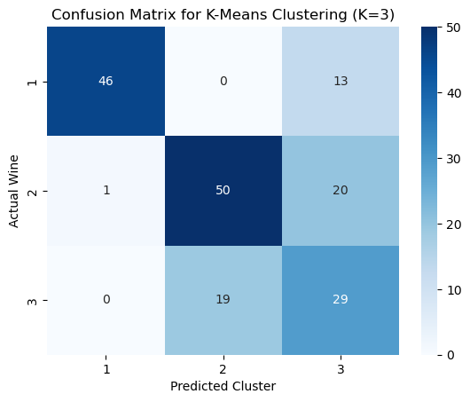

```python
wine_features = wine.drop(columns=['Wine'])

kmeans = KMeans(n_clusters=3, random_state=0)
kmeans.fit(wine_features)

cluster_labels = kmeans.labels_

wine['cluster'] = cluster_labels

wine_mode = wine.groupby('cluster')['Wine'].apply(lambda x: x.mode().iloc[0]).to_dict()

wine['cluster_wine'] = wine['cluster'].map(wine_mode)

conf_matrix = confusion_matrix(wine['Wine'], wine['cluster_wine'])

sns.heatmap(conf_matrix, annot=True, fmt='d', cmap='Blues',
            xticklabels=np.unique(wine['cluster_wine']),
            yticklabels=np.unique(wine['Wine']))
plt.xlabel('Predicted Cluster')
plt.ylabel('Actual Wine')
plt.title('Confusion Matrix for K-Means Clustering (K=3)')
plt.show()
```

## Wine Data Conclusion

The matrix above shows that the wine has good spearation in the wine but also having some overlap in the different types of wine. Similar to Iris the k-means identified the groups in the wine dataset.

# Task C: WeatherAUS data

Perform K-Means clustering on the dataset, weatherAUS.csv (from the Kaggle site). The details about this data can be found here. Again, you will have to remove a few columns from this data and make it useful for clustering. Play with a range of values of K, from, K=2 to K=6 and try to visualise the results of clustering using two-dimensional scatter plots.

```python
weather = pd.read_csv("Unit06 weatherAUS.csv")
weather.head(5)
```

|  | MinTemp | MaxTemp | Rainfall | WindGustSpeed | WindSpeed9am | WindSpeed3pm | Humidity9am | Humidity3pm | Pressure9am | Pressure3pm | Temp9am | Temp3pm | RainToday | RainTomorrow |
| --- | --- | --- | --- | --- | --- | --- | --- | --- | --- | --- | --- | --- | --- | --- |
| 0 | 13.4 | 22.9 | 0.6 | 44.0 | 20.0 | 24.0 | 71.0 | 22.0 | 1007.7 | 1007.1 | 16.9 | 21.8 | No | No |
| 1 | 7.4 | 25.1 | 0.0 | 44.0 | 4.0 | 22.0 | 44.0 | 25.0 | 1010.6 | 1007.8 | 17.2 | 24.3 | No | No |
| 2 | 12.9 | 25.7 | 0.0 | 46.0 | 19.0 | 26.0 | 38.0 | 30.0 | 1007.6 | 1008.7 | 21.0 | 23.2 | No | No |
| 3 | 9.2 | 28.0 | 0.0 | 24.0 | 11.0 | 9.0 | 45.0 | 16.0 | 1017.6 | 1012.8 | 18.1 | 26.5 | No | No |
| 4 | 17.5 | 32.3 | 1.0 | 41.0 | 7.0 | 20.0 | 82.0 | 33.0 | 1010.8 | 1006.0 | 17.8 | 29.7 | No | No |

```
   MinTemp  MaxTemp  Rainfall  WindGustSpeed  WindSpeed9am  WindSpeed3pm  \
0     13.4     22.9       0.6           44.0          20.0          24.0
1      7.4     25.1       0.0           44.0           4.0          22.0
2     12.9     25.7       0.0           46.0          19.0          26.0
3      9.2     28.0       0.0           24.0          11.0           9.0
4     17.5     32.3       1.0           41.0           7.0          20.0

   Humidity9am  Humidity3pm  Pressure9am  Pressure3pm  Temp9am  Temp3pm
0         71.0         22.0       1007.7       1007.1     16.9     21.8
1         44.0         25.0       1010.6       1007.8     17.2     24.3
2         38.0         30.0       1007.6       1008.7     21.0     23.2
3         45.0         16.0       1017.6       1012.8     18.1     26.5
4         82.0         33.0       1010.8       1006.0     17.8     29.7
[2 2 2 ... 2 2 0]
```

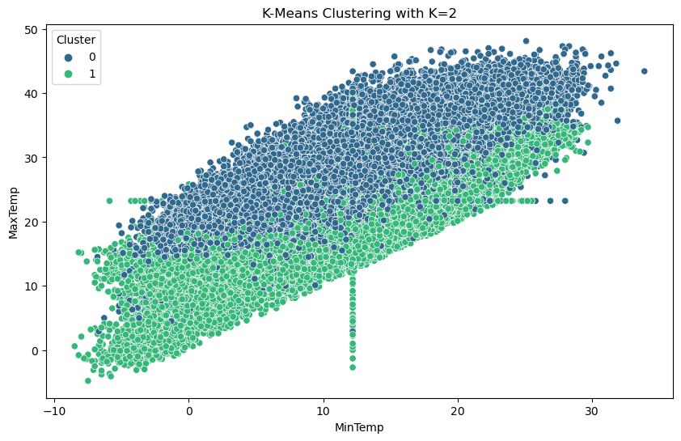

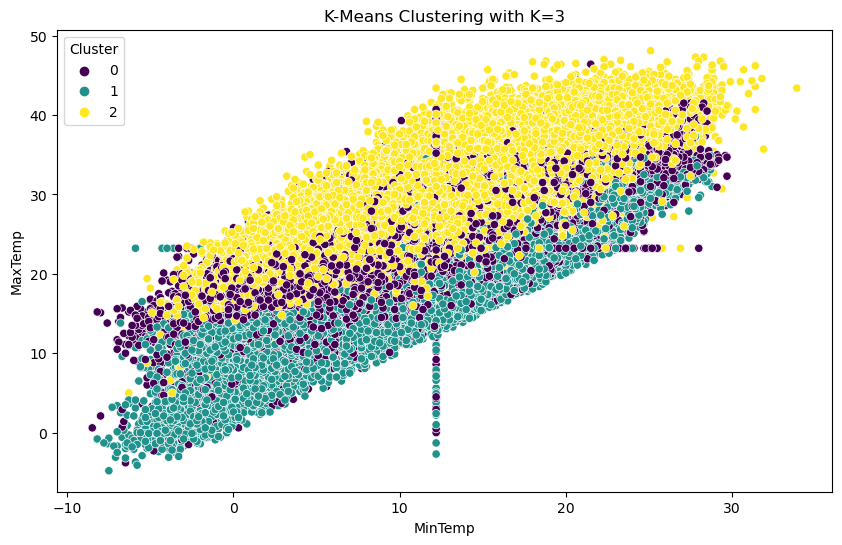

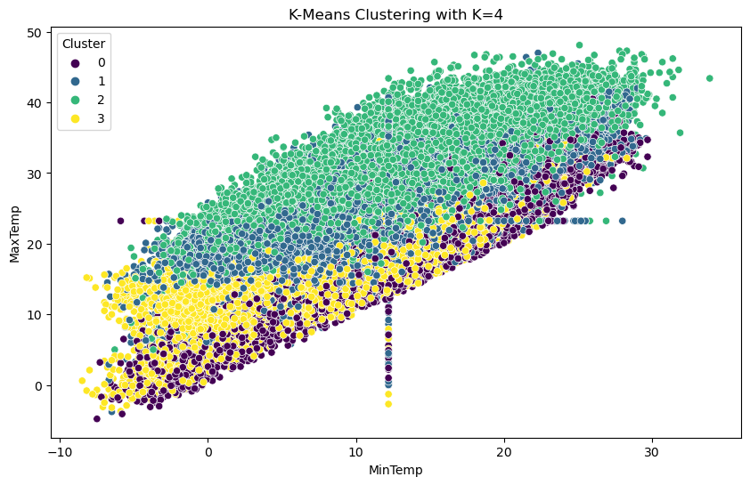

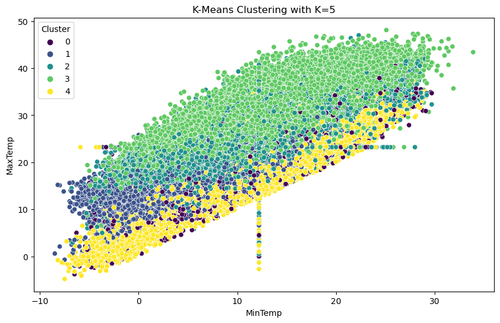

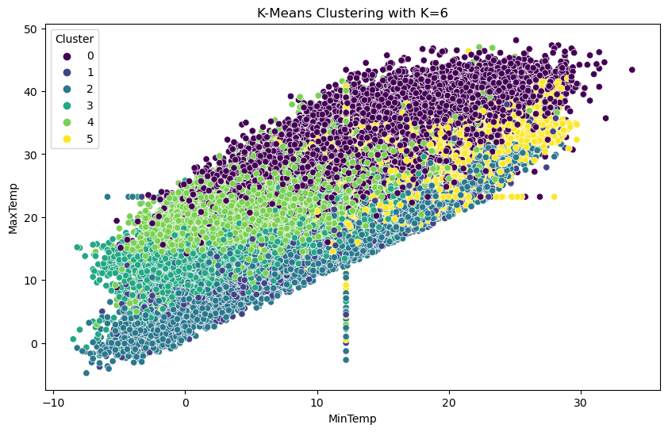

```python
weather = weather.drop(columns=['RainToday', 'RainTomorrow'])

# Handle missing values by filling them with the mean of the column
weather = weather.fillna(weather.mean())

# Display the first few rows of the preprocessed dataset
print(weather.head())

# Function to perform K-Means clustering and return cluster labels
def kmeans_clustering(data, n_clusters):
    kmeans = KMeans(n_clusters=n_clusters, random_state=0)
    kmeans.fit(data)
    return kmeans.labels_

# Range of K values
k_values = range(2, 7)

# Dictionary to store cluster labels for different K values
cluster_labels_dict = {}

for k in k_values:
    cluster_labels_dict[k] = kmeans_clustering(weather, k)

# Display cluster labels for K=3 as an example
print(cluster_labels_dict[3])

# Function to plot the clusters
def plot_clusters(data, labels, k):
    plt.figure(figsize=(10, 6))
    sns.scatterplot(x=data['MinTemp'], y=data['MaxTemp'], hue=labels, palette='viridis')
    plt.title(f'K-Means Clustering with K={k}')
    plt.xlabel('MinTemp')
    plt.ylabel('MaxTemp')
    plt.legend(title='Cluster')
    plt.show()

# Plot clusters for K=2 to K=6
for k in k_values:
    plot_clusters(weather, cluster_labels_dict[k], k)
```

## WeatherAUS Data Conclusion

The 2 to 6 k-means clustering shows a broard range of patterns between max and min temprature, the right amount of clusters is 3-4 in this case since too many can lead to overfitting in this case when you get into 5-6 but 2 clusters can seem too small of an ammount. Therefore 3-4 provides the right amount of granularity where more clusters have too much overlap.